# Project Code

The S&P

Author

Kota Suzuki, Radhika Todi, Naoki Ito, and Julianne Sun

Published

March 7, 2023

Abstract

*This file contains the code for the project on The S&P’s endeavor to classify companies’ goodness of ethical management practices solely based on financial indicators, as part of the STAT303-2 course in Winter 2023*.

## 1 Data quality check / cleaning / preparation

Put code with comments. The comments should explain the code such that it can be easily understood. You may put text *(in a markdown cell)* before a large chunk of code to explain the overall purpose of the code, if it is not intuitive. **Put the name of the person / persons who contributed to each code chunk / set of code chunks.** An example is given below.

```python
# importing necessary packages
import pandas as pd
import numpy as np
import statsmodels.formula.api as sm
import seaborn as sns
import matplotlib.pyplot as plt
import datetime
import itertools
import time
from sklearn.metrics import roc_curve, auc
from sklearn.metrics import precision_recall_curve
```

```python
pd.set_option('display.max_columns', None)
import warnings
warnings.filterwarnings("ignore")

# reading in all of our data
esg = pd.read_csv('ESG_scoredata/ESG_scoredata.csv')
ratios = pd.read_csv('ESG_scoredata/financial_ratios.csv')
securitydaily = pd.read_csv('ESG_scoredata/security_daily.csv')
```

### 1.1 Data quality check

*By Kota Suzuki*

#### 1.1.1 Distribution of numerical variables

The code below visualizes the distribution of all the variables in the dataset, and their association with the response.

```python
# distribution of numerical variables in esg dataset
esg.describe()
```

|  | institutionid | assessmentyear | scorevalue | scoreweight | industryrank | companyid | gvkey |
| --- | --- | --- | --- | --- | --- | --- | --- |
| count | 6.486140e+05 | 648614.000000 | 638002.000000 | 624328.000000 | 638002.000000 | 6.486140e+05 | 648614.000000 |
| mean | 3.976814e+06 | 2018.917060 | 26.108341 | 7.783369 | 69.895756 | 3.479973e+07 | 56410.346328 |
| std | 2.089602e+06 | 2.475546 | 23.463936 | 10.165602 | 84.848632 | 9.872846e+07 | 66059.249599 |
| min | 1.000030e+05 | 2013.000000 | 0.000000 | 1.000000 | 1.000000 | 1.867100e+04 | 1004.000000 |
| 25% | 4.048147e+06 | 2017.000000 | 3.000000 | 3.000000 | 16.000000 | 1.894880e+05 | 9850.000000 |
| 50% | 4.152463e+06 | 2020.000000 | 22.000000 | 4.000000 | 40.000000 | 3.149600e+05 | 24447.000000 |
| 75% | 4.810658e+06 | 2021.000000 | 40.000000 | 7.000000 | 89.000000 | 4.180463e+06 | 105365.000000 |
| max | 2.972477e+07 | 2022.000000 | 100.000000 | 55.000000 | 743.000000 | 1.678014e+09 | 345189.000000 |

```python
# distribution of numerical variables in ratios dataset
ratios.describe()
```

|  | gvkey | bm | gpm | roe | debt_assets | curr_ratio | at_turn |
| --- | --- | --- | --- | --- | --- | --- | --- |
| count | 435916.000000 | 414052.000000 | 410332.000000 | 405950.000000 | 433393.000000 | 356166.000000 | 410741.000000 |
| mean | 66462.537129 | 0.899641 | -6.109597 | -0.739567 | 0.584153 | 4.376325 | 0.778087 |
| std | 68039.128791 | 139.078975 | 177.892534 | 82.514665 | 0.847386 | 90.881193 | 0.809226 |
| min | 1004.000000 | 0.000000 | -28202.000000 | -21888.000000 | 0.000000 | 0.000000 | 0.000000 |
| 25% | 14793.000000 | 0.247000 | 0.215000 | -0.139000 | 0.346000 | 1.332000 | 0.215000 |
| 50% | 29914.000000 | 0.491000 | 0.391000 | 0.060000 | 0.571000 | 2.100000 | 0.602000 |
| 75% | 133868.000000 | 0.830000 | 0.656000 | 0.133000 | 0.799000 | 3.700000 | 1.084000 |
| max | 349972.000000 | 89351.100000 | 2.628000 | 5303.740000 | 340.654000 | 13528.100000 | 35.112000 |

```python
# distribution of numerical variables in security dataset
securitydaily.describe()
```

|  | gvkey | ajexdi | cshoc | prccd | trfd |
| --- | --- | --- | --- | --- | --- |
| count | 4.693155e+07 | 4.691145e+07 | 4.590000e+07 | 4.691017e+07 | 2.729079e+07 |
| mean | 9.494989e+04 | 9.865210e-01 | 2.882302e+09 | 7.643682e+01 | 2.660211e+09 |
| std | 7.632956e+04 | 3.289092e+00 | 1.954235e+12 | 4.135382e+03 | 3.270882e+11 |
| min | 1.003000e+03 | 0.000000e+00 | 0.000000e+00 | 0.000000e+00 | 1.000000e+00 |
| 25% | 2.354600e+04 | 1.000000e+00 | 7.637000e+06 | 3.500000e-01 | 1.048558e+00 |
| 50% | 6.585100e+04 | 1.000000e+00 | 3.402600e+07 | 9.990000e+00 | 1.218091e+00 |
| 75% | 1.707810e+05 | 1.000000e+00 | 1.132790e+08 | 2.590000e+01 | 1.738440e+00 |
| max | 3.539450e+05 | 1.000000e+03 | 1.582449e+15 | 8.711790e+06 | 4.408022e+13 |

#### 1.1.2 Missing values

```python
# number of missing values for esg dataset
esg.isnull().sum()
```

```
scoreid                              0
dimensionscoreid                     0
institutionid                        0
assessmentyear                       0
scoredate                            0
csaindustryname                      0
csaindustrygroupname                 0
csaindustryclassificationname        0
csasectorname                        0
scoretype                            0
dimensionname                        0
aspectname                           0
scorevalue                       10612
scoreweight                      24286
industryrank                     10612
companyid                            0
gvkey                                0
ticker                            1205
companyname                          0
country                              0
simpleindustry                       0
dtype: int64
```

```python
# number of missing values for ratios dataset
ratios.isnull().sum()
```

```
gvkey               0
adate            2727
qdate               0
public_date         0
bm              21864
gpm             25584
roe             29966
debt_assets      2523
curr_ratio      79750
at_turn         25175
divyield       269366
TICKER           2757
cusip            2423
dtype: int64
```

```python
# number of missing values for security dataset
securitydaily.isnull().sum()
```

```
gvkey              0
iid                0
datadate           0
tic             4933
cusip              0
conm               0
ajexdi         20099
cshoc        1031557
prccd          21382
trfd        19640760
dtype: int64
```

#### 1.1.3 Distribution of categorical variables

```python
# number of unique values for industry sector
esg['csasectorname'].unique()
```

```
array(['Financials', 'Information Technology', 'Consumer Discretionary',
       'Real Estate', 'Health Care', 'Industrials', 'Utilities',
       'Materials', 'Consumer Staples', 'Energy',
       'Communication Services'], dtype=object)
```

```python
# number of unique values for environment aspect name
esg['aspectname'].value_counts()
```

```
Business Ethics                      24457
Risk & Crisis Management             24336
Corporate Governance                 24307
Labor Practice Indicators            24295
Talent Attraction & Retention        24287
                                     ...
Circular Fashion                        18
Sustainable Management of Forests        9
Responsible Marketing Policies           9
Combatting Smuggling                     9
Ecosystem Services                       3
Name: aspectname, Length: 111, dtype: int64
```

#### 1.1.4 Correlation

To visualize the correlation between predictors and response variable, we will be using a polished dataset that was created in the subsequent *data preparation* section.

```python
# calculating correlation coefficient
environmentcopy.corrwith(environmental["scorevalue"])
```

```
scorevalue       1.000000
scoreweight      0.185021
industryrank    -0.445278
companyid       -0.117075
gvkey           -0.163545
bm              -0.012526
gpm              0.014140
roe              0.033438
debt_assets      0.113498
curr_ratio      -0.156558
at_turn         -0.006598
year            -0.207155
mktcap_annual    0.280045
dtype: float64
```

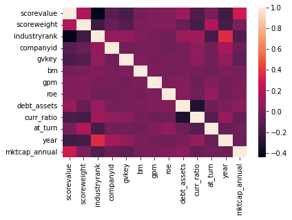

```python
# plotting heatmap
sns.heatmap(environmentcopy.corr())
```

### 1.2 Data preparation and Data cleaning

*By Naoki Ito, Kota Suzuki, and Radhika Todi*

The following data preparation steps helped us to prepare our data for implementing various modeling / validation techniques:

1. Since our question revolves around classifying ethical, environmental management practices solely based on financial indicators, we must calculate multiple variables from various different datasets
2. Once calculating the new financial variables and merging, we separate the ESG dataset into the three respective categories — environment, social, governmental.
3. We normalize the `scorevalue` variable for our classification model
4. Lastly, we split the final dataset into training and testing

#### 1.2.1 Market Capitalization Calculation (annual average for each company)

```python
# modifying security dataset by dropping na values
securitydaily.dropna(subset=['ajexdi','cshoc','prccd','tic'],inplace =True)

# calculating pure market cap
securitydaily['mktcap']= securitydaily['prccd']*securitydaily['cshoc']/securitydaily['ajexdi']

# producing accurate time measurements to calculate annual market cap average
securitydaily['datadate'] = pd.to_datetime(securitydaily['datadate'])
securitydaily['year'] = securitydaily['datadate'].dt.year

# calculating annual market cap average
securitydaily['mktcap_annual'] = securitydaily.groupby(['gvkey','tic','year'])['mktcap'].transform('mean')

# dropping unnecessary variables and grouping to get final market cap dataset
mktcap_annualdata = securitydaily.drop(columns=['iid', 'datadate','ajexdi','cshoc','prccd','trfd','mktcap','cusip']).groupby(['gvkey','tic','year']).first().reset_index()
```

#### 1.2.2 Financial Ratio Data Cleaning

Creating annual data, ‘year’ corresponds to the year in `adate`, take the first observation in the same `adate` group as a representative for each company-year level

```python
ratios_cleaned = ratios.drop(columns=['qdate', 'public_date','cusip']).groupby(['adate','gvkey']).first().reset_index()
ratios_cleaned['adate'] = pd.to_datetime(ratios_cleaned['adate'])
ratios_cleaned['year'] = ratios_cleaned['adate'].dt.year
ratios_cleaned = ratios_cleaned.drop(columns=['adate','divyield'])
```

#### 1.2.3 Merging datasets

```python
# merging esg dataset and financial ratios dataset
esg_ratio = pd.merge(esg, ratios_cleaned, left_on=['gvkey','assessmentyear','ticker'],right_on=['gvkey','year','TICKER'], how='inner')

# dropping observations without scorevalue data
esg_ratio.dropna(subset=['scorevalue'],inplace =True)

# dropping unnecessary columns
esg_ratio.drop(columns=['scoreid','dimensionscoreid','institutionid','assessmentyear','TICKER'],inplace=True)

# combining the mktcap data to the esg data and financial ratio data
combined_df = pd.merge(esg_ratio, mktcap_annualdata, left_on=['gvkey','year','ticker'],right_on=['gvkey','year','tic'], how='inner')
```

```python
# subsetting to dimensional datasets
environmental = combined_df.loc[combined_df['dimensionname'] == 'Environmental Dimension' ]
social = combined_df.loc[combined_df['dimensionname'] == 'Social Dimension' ]
governance = combined_df.loc[combined_df['dimensionname'] == 'Economic Governance Dimension']
```

#### 1.2.4 Preparing data for modelling

```python
# Selecting the Environmental Dimension aspect based on EDA findings
data_subset = environmental[environmental.aspectname=='Environmental Dimension']

# normalizing score value to a 0-1 scale
environmentcopy = data_subset.copy()
environmentcopy['scorevalue'] = (environmentcopy['scorevalue'] - environmentcopy['scorevalue'].min()) / (environmentcopy['scorevalue'].max() - environmentcopy['scorevalue'].min())

# Defining score values above the median score as good(1) and score values below the median score as bad(0)
environmentcopy.loc[:,'scorevalue'] = environmentcopy.loc[:,'scorevalue'].apply(lambda x: 1 if x>environmentcopy.scorevalue.median() else 0)

#Randomly selecting 80% of observations as training data as 20% of the observations as testing data
training_data = environmentcopy.sample(frac=0.8, random_state=20)
testing_data = environmentcopy.drop(training_data.index)
```

## 2 Exploratory data analysis

Put code with comments. The comments should explain the code such that it can be easily understood. You may put text *(in a markdown cell)* before a large chunk of code to explain the overall purpose of the code, if it is not intuitive. **Put the name of the person / persons who contributed to each code chunk / set of code chunks.**

*By Kota Suzuki, Naoki Ito, Radhika Todi*

#### 2.0.1 `mktcap_annual`

```
Optimization terminated successfully.
         Current function value: 0.635926
         Iterations 8
```

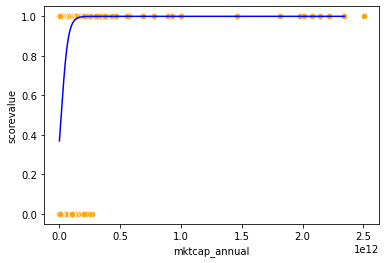

```python
# calculating log of marketcap
environmentcopy['log_mktcap'] = np.log(environmentcopy['mktcap_annual'])
training_data['log_mktcap'] = np.log(training_data['mktcap_annual'])
testing_data['log_mktcap'] = np.log(testing_data['mktcap_annual'])

# developing logistic regression
logit_model = sm.logit(formula = 'scorevalue~mktcap_annual', data = training_data).fit()

# visualizing model
sns.scatterplot(x = 'mktcap_annual', y = 'scorevalue', data = environmentcopy, color = 'orange')
sns.lineplot(x = 'mktcap_annual', y= logit_model.predict(testing_data), data = environmentcopy, color = 'blue')
```

```
Optimization terminated successfully.
         Current function value: 0.617318
         Iterations 5
Optimization terminated successfully.
         Current function value: 0.615746
         Iterations 6
-9078.2747392161
-9055.159612602729
```

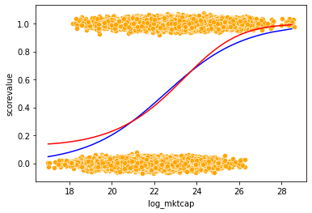

```python
# defining jitter function
def jitter(values,j):
    return values + np.random.normal(j,0.02,values.shape)
sns.scatterplot(x = jitter(environmentcopy.log_mktcap,0), y = jitter(environmentcopy.scorevalue,0), data = environmentcopy, color = 'orange')

# plotting line for no transformation
logit_model = sm.logit(formula = 'scorevalue~log_mktcap', data = training_data).fit()
sns.lineplot(x = 'log_mktcap', y= logit_model.predict(testing_data), data = environmentcopy, color = 'blue')

# yes transformation
logit_model_transformed = sm.logit(formula = 'scorevalue~log_mktcap+I(log_mktcap**2)', data = training_data).fit()
sns.lineplot(x = 'log_mktcap', y= logit_model_transformed.predict(testing_data), data = environmentcopy, color = 'red')
print(logit_model.llf)
print(logit_model_transformed.llf)
```

#### 2.0.2 `curr_ratio`

```
Optimization terminated successfully.
         Current function value: 0.674812
         Iterations 6
Optimization terminated successfully.
         Current function value: 0.669178
         Iterations 9
-8263.073389467307
-8194.081504340116
```

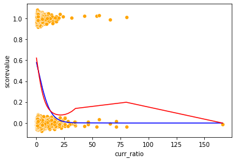

```python
# calculating log of current ratio
environmentcopy['log_currratio'] = np.log(environmentcopy['curr_ratio'])
training_data['log_currratio'] = np.log(training_data['curr_ratio'])
testing_data['log_currratio'] = np.log(testing_data['curr_ratio'])

# plotting line for no transformation
sns.scatterplot(x = jitter(environmentcopy.curr_ratio,0), y = jitter(environmentcopy.scorevalue,0), data = environmentcopy, color = 'orange')
logit_model = sm.logit(formula = 'scorevalue~curr_ratio', data = training_data).fit()
sns.lineplot(x = 'curr_ratio', y= logit_model.predict(testing_data), data = environmentcopy, color = 'blue')

# yes transformation
logit_model_transformed = sm.logit(formula = 'scorevalue~curr_ratio+I(curr_ratio**2)+I(curr_ratio**3)', data = training_data).fit()
sns.lineplot(x = 'curr_ratio', y= logit_model_transformed.predict(testing_data), data = environmentcopy, color = 'red')

print(logit_model.llf)
print(logit_model_transformed.llf)
```

```
Optimization terminated successfully.
         Current function value: 0.672610
         Iterations 5
-8236.114815163657
```

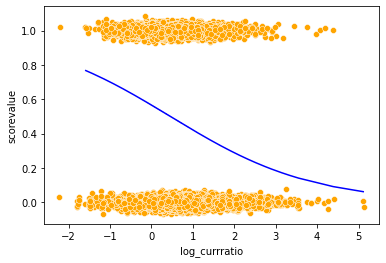

```python
# Jittering points to better see the density of points in any given region of the plot
sns.scatterplot(x = jitter(environmentcopy.log_currratio,0), y = jitter(environmentcopy.scorevalue,0), data = environmentcopy, color = 'orange')

# plotting line for yes transformation
logit_model = sm.logit(formula = 'scorevalue~log_currratio', data = training_data).fit()
sns.lineplot(x = 'log_currratio', y= logit_model.predict(testing_data), data = environmentcopy, color = 'blue')

print(logit_model.llf)
```

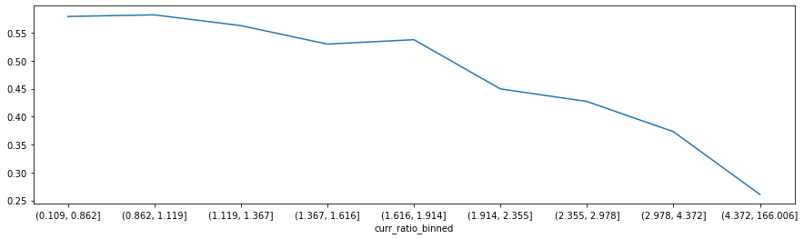

```python
# binning curr_ratio
curr_ratio_binned = pd.qcut(environmentcopy['curr_ratio'],9,retbins = True)
environmentcopy['curr_ratio_binned'] = curr_ratio_binned[0]
data_grouped = environmentcopy.groupby('curr_ratio_binned')
ax = data_grouped['scorevalue'].mean().plot()
ax.figure.set_figwidth(15)
```

The two visualizations show that taking $log()$ of the `curr_ratio` variable is an effective transformation. The last linegraph effectively visualizes the relationship between a binned `curr_ratio` and the `scorevalue` — highlighting the negative correlation — but the binned `curr_ratio` variable has no effect on the model itself.

#### 2.0.3 debt_assets

```
Optimization terminated successfully.
         Current function value: 0.685759
         Iterations 4
-10084.777643303485
```

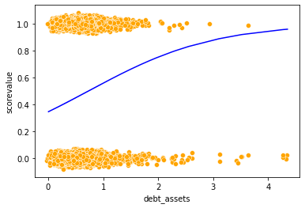

```python
# plotting line for no transformation
sns.scatterplot(x = jitter(environmentcopy.debt_assets,0), y = jitter(environmentcopy.scorevalue,0), data = environmentcopy, color = 'orange')
logit_model = sm.logit(formula = 'scorevalue~debt_assets', data = training_data).fit()
sns.lineplot(x = 'debt_assets', y= logit_model.predict(testing_data), data = environmentcopy, color = 'blue')
print(logit_model.llf)
```

```python
# defining function to bin debt assets so that it can be applied to both the test and train datasets
def var_transform(data):
    binned_debt_assets = pd.qcut(environmentcopy['debt_assets'],10,retbins=True)
    bins = binned_debt_assets[1]
    data['binned_debt_assets'] = pd.cut(data['debt_assets'],bins = bins)
    dum = pd.get_dummies(data.binned_debt_assets,drop_first = True)
    dum.columns = ['debt_assets'+str(x) for x in range(1,len(bins)-1)]
    data = pd.concat([data,dum], axis = 1)
    return data

training_data = var_transform(training_data)
testing_data = var_transform(testing_data)
```

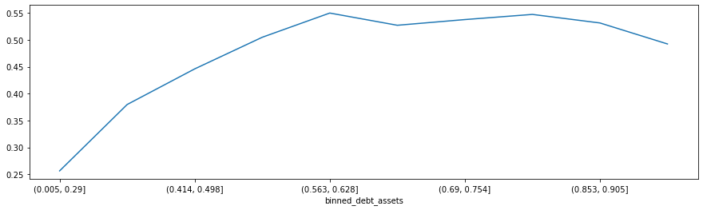

```python
# binning debt_assets
data_grouped = training_data.groupby('binned_debt_assets')
ax = data_grouped['scorevalue'].mean().plot()
ax.figure.set_figwidth(15)
```

```
Optimization terminated successfully.
         Current function value: 0.675617
         Iterations 5
-9935.61791768595
```

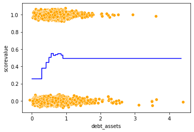

```python
# Model with binned debt_assets
sns.scatterplot(x = jitter(training_data.debt_assets,0), y = jitter(training_data.scorevalue,0), data = training_data, color = 'orange')
logit_model = sm.logit(formula = 'scorevalue~' + '+'.join(['debt_assets'+str(x) for x in range(1,10)]), data = training_data).fit()
sns.lineplot(x = 'debt_assets', y= logit_model.predict(training_data), data = training_data, color = 'blue')
print(logit_model.llf)
```

With the two visualizations, we see that binning the `debt_assets` variable is a very effective transformation that more clearly shows the trend or relationship between `debt_assets` and `scorevalue`.

#### 2.0.4 `csasectorname`

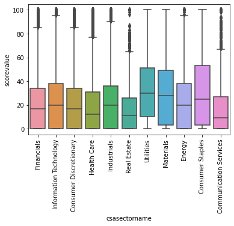

```python
# building boxplot for sectors to see distribution
sns.boxplot(data=environmental, x="csasectorname", y="scorevalue")
plt.xticks(rotation=90);
```

Intuitively, `csasectorname` which represents the industry an observation belongs in, would be a strong predictor for `scorevalue` since different industry sectors should interact with the environment in different capacities and manners.

## 3 Developing the model

Put code with comments. The comments should explain the code such that it can be easily understood. You may put text *(in a markdown cell)* before a large chunk of code to explain the overall purpose of the code, if it is not intuitive. **Put the name of the person / persons who contributed to each code chunk / set of code chunks.**

*By Radhika Todi, Julianne Sun*

#### 3.0.1 Base Model

```python
# Creating a base model with all the available variables as predictors (no selection and no transformations)
logit_model_base = sm.logit(formula = 'scorevalue~mktcap_annual+curr_ratio+debt_assets+roe+gpm+csasectorname+at_turn+bm', data = training_data).fit()
logit_model_base.summary()
```

```
Optimization terminated successfully.
         Current function value: 0.609047
         Iterations 8
```

Logit Regression Results

| Dep. Variable: | scorevalue | No. Observations: | 11581 |
| --- | --- | --- | --- |
| Model: | Logit | Df Residuals: | 11563 |
| Method: | MLE | Df Model: | 17 |
| Date: | Tue, 07 Mar 2023 | Pseudo R-squ.: | 0.1206 |
| Time: | 15:42:47 | Log-Likelihood: | -7053.4 |
| converged: | True | LL-Null: | -8020.3 |
| Covariance Type: | nonrobust | LLR p-value: | 0.000 |

|  | coef | std err | z | P>\|z\| | [0.025 | 0.975] |
| --- | --- | --- | --- | --- | --- | --- |
| Intercept | -2.2602 | 0.155 | -14.580 | 0.000 | -2.564 | -1.956 |
| csasectorname[T.Consumer Discretionary] | 1.1866 | 0.136 | 8.707 | 0.000 | 0.920 | 1.454 |
| csasectorname[T.Consumer Staples] | 1.4868 | 0.151 | 9.863 | 0.000 | 1.191 | 1.782 |
| csasectorname[T.Energy] | 1.3812 | 0.148 | 9.327 | 0.000 | 1.091 | 1.671 |
| csasectorname[T.Financials] | 1.3447 | 0.198 | 6.807 | 0.000 | 0.958 | 1.732 |
| csasectorname[T.Health Care] | 0.6967 | 0.137 | 5.102 | 0.000 | 0.429 | 0.964 |
| csasectorname[T.Industrials] | 1.5171 | 0.134 | 11.340 | 0.000 | 1.255 | 1.779 |
| csasectorname[T.Information Technology] | 1.2401 | 0.133 | 9.321 | 0.000 | 0.979 | 1.501 |
| csasectorname[T.Materials] | 2.0416 | 0.145 | 14.122 | 0.000 | 1.758 | 2.325 |
| csasectorname[T.Real Estate] | 0.4827 | 0.389 | 1.240 | 0.215 | -0.281 | 1.246 |
| csasectorname[T.Utilities] | 1.7860 | 0.152 | 11.763 | 0.000 | 1.488 | 2.084 |
| mktcap_annual | 3.229e-11 | 1.42e-12 | 22.694 | 0.000 | 2.95e-11 | 3.51e-11 |
| curr_ratio | -0.0315 | 0.011 | -2.782 | 0.005 | -0.054 | -0.009 |
| debt_assets | 1.0849 | 0.118 | 9.214 | 0.000 | 0.854 | 1.316 |
| roe | -0.0038 | 0.008 | -0.456 | 0.648 | -0.020 | 0.013 |
| gpm | 0.0002 | 0.000 | 0.653 | 0.514 | -0.000 | 0.001 |
| at_turn | -0.0387 | 0.034 | -1.149 | 0.251 | -0.105 | 0.027 |
| bm | -0.0067 | 0.009 | -0.765 | 0.444 | -0.024 | 0.010 |

```
Classification accuracy = 65.9%
```

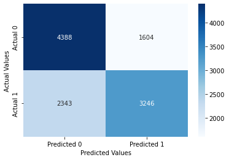

```python
# definining and running function for confusion matrix train
def confusion_matrix_train(model,cutoff=0.49):
    cm_df = pd.DataFrame(model.pred_table(threshold = cutoff))
    cm_df.columns = ['Predicted 0', 'Predicted 1']
    cm_df = cm_df.rename(index={0: 'Actual 0',1: 'Actual 1'})
    cm = np.array(cm_df)
    sns.heatmap(cm_df, annot=True, cmap='Blues', fmt='g')
    plt.ylabel("Actual Values")
    plt.xlabel("Predicted Values")
    accuracy = (cm[0,0]+cm[1,1])/cm.sum()
    print("Classification accuracy = {:.1%}".format(accuracy))

confusion_matrix_train(logit_model_base)
```

```
Classification accuracy = 65.0%
```

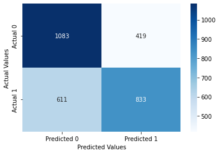

```python
# defining and running function for confusion matrix test
def confusion_matrix_test(data,actual_values,model,cutoff=0.49):
    pred_values = model.predict(data)
    bins=np.array([0,cutoff,1])
    cm = np.histogram2d(actual_values, pred_values, bins=bins)[0]
    cm_df = pd.DataFrame(cm)
    cm_df.columns = ['Predicted 0','Predicted 1']
    cm_df = cm_df.rename(index={0: 'Actual 0',1:'Actual 1'})
    accuracy = (cm[0,0]+cm[1,1])/cm.sum()
    sns.heatmap(cm_df, annot=True, cmap='Blues', fmt='g')
    plt.ylabel("Actual Values")
    plt.xlabel("Predicted Values")
    print("Classification accuracy = {:.1%}".format(accuracy))

confusion_matrix_test(testing_data,testing_data.scorevalue,logit_model_base)
```

#### 3.0.2 Best Subset Selection

```python
# conducting best subset selection to select best interaction terms
X = training_data[['log_mktcap','log_currratio','roe','debt_assets']]
X_backup = training_data[['log_mktcap','log_currratio','roe','debt_assets']]

for combo in itertools.combinations(X_backup.columns, 2):
    training_data['_'.join(combo)] = training_data[combo[0]]*training_data[combo[1]]
    testing_data['_'.join(combo)] = testing_data[combo[0]]*testing_data[combo[1]]
    X.loc[:,'_'.join(combo)] = training_data.loc[:,'_'.join(combo)]

# defining necessary functions
def processSubset(predictor_subset):
    model = sm.ols('scorevalue~' + '+'.join(predictor_subset),data = training_data).fit()
    Rsquared = model.rsquared
    return {"model":model, "Rsquared":Rsquared}

def getBest_model(k):
    tic = time.time()
    results = []
    for combo in itertools.combinations(X.columns, k):
        results.append(processSubset((list(combo))))

    # Wrap everything up in a dataframe
    models = pd.DataFrame(results)

    # Choose the model with the highest RSS
    best_model = models.loc[models['Rsquared'].argmax()]

    toc = time.time()
    print("Processed", models.shape[0], "models on", k, "predictors in", (toc-tic), "seconds.")
    return best_model
```

```python
# running best subset selection
models_best = pd.DataFrame(columns=["Rsquared", "model"])

tic = time.time()
for i in range(1,1+X.shape[1]):
    models_best.loc[i] = getBest_model(i)

toc = time.time()
print("Total elapsed time:", (toc-tic), "seconds.")
```

```
Processed 10 models on 1 predictors in 0.0899813175201416 seconds.
Processed 45 models on 2 predictors in 0.32770609855651855 seconds.
Processed 120 models on 3 predictors in 0.8863043785095215 seconds.
Processed 210 models on 4 predictors in 1.6642041206359863 seconds.
Processed 252 models on 5 predictors in 2.141430139541626 seconds.
Processed 210 models on 6 predictors in 2.1307640075683594 seconds.
Processed 120 models on 7 predictors in 1.244201898574829 seconds.
Processed 45 models on 8 predictors in 0.5383789539337158 seconds.
Processed 10 models on 9 predictors in 0.12891411781311035 seconds.
Processed 1 models on 10 predictors in 0.014359712600708008 seconds.
Total elapsed time: 9.216908931732178 seconds.
```

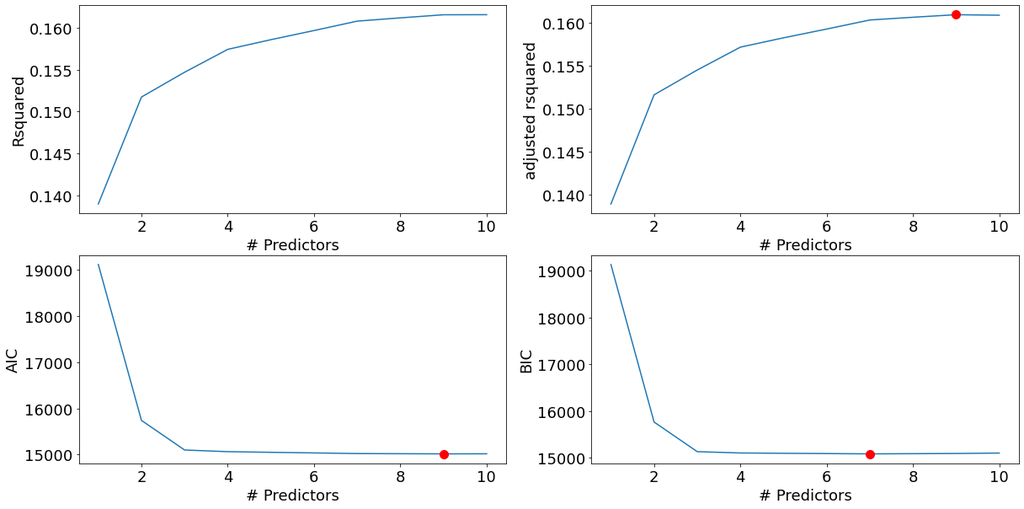

```python
# choosing best number of predictor with BIC criteria
def best_sub_plots():
    plt.figure(figsize=(20,10))
    plt.rcParams.update({'font.size': 18, 'lines.markersize': 10})

    # Set up a 2x2 grid so we can look at 4 plots at once
    plt.subplot(2, 2, 1)

    # We will now plot a red dot to indicate the model with the largest adjusted R^2 statistic.
    # The argmax() function can be used to identify the location of the maximum point of a vector
    plt.plot(models_best["Rsquared"])
    plt.xlabel('# Predictors')
    plt.ylabel('Rsquared')

    # We will now plot a red dot to indicate the model with the largest adjusted R^2 statistic.
    # The argmax() function can be used to identify the location of the maximum point of a vector

    rsquared_adj = models_best.apply(lambda row: row[1].rsquared_adj, axis=1)

    plt.subplot(2, 2, 2)
    plt.plot(rsquared_adj)
    plt.plot(1+rsquared_adj.argmax(), rsquared_adj.max(), "or")
    plt.xlabel('# Predictors')
    plt.ylabel('adjusted rsquared')

    # We'll do the same for AIC and BIC, this time looking for the models with the SMALLEST statistic
    aic = models_best.apply(lambda row: row[1].aic, axis=1)

    plt.subplot(2, 2, 3)
    plt.plot(aic)
    plt.plot(1+aic.argmin(), aic.min(), "or")
    plt.xlabel('# Predictors')
    plt.ylabel('AIC')

    bic = models_best.apply(lambda row: row[1].bic, axis=1)

    plt.subplot(2, 2, 4)
    plt.plot(bic)
    plt.plot(1+bic.argmin(), bic.min(), "or")
    plt.xlabel('# Predictors')
    plt.ylabel('BIC')
best_sub_plots()
```

```python
# modeling best interaction model
best_interaction_model = models_best['model'][7]
best_interaction_model.summary()
```

OLS Regression Results

| Dep. Variable: | scorevalue | R-squared: | 0.161 |
| --- | --- | --- | --- |
| Model: | OLS | Adj. R-squared: | 0.160 |
| Method: | Least Squares | F-statistic: | 322.0 |
| Date: | Tue, 07 Mar 2023 | Prob (F-statistic): | 0.00 |
| Time: | 15:48:54 | Log-Likelihood: | -7503.2 |
| No. Observations: | 11773 | AIC: | 1.502e+04 |
| Df Residuals: | 11765 | BIC: | 1.508e+04 |
| Df Model: | 7 |  |  |
| Covariance Type: | nonrobust |  |  |

|  | coef | std err | t | P>\|t\| | [0.025 | 0.975] |
| --- | --- | --- | --- | --- | --- | --- |
| Intercept | -1.1681 | 0.175 | -6.658 | 0.000 | -1.512 | -0.824 |
| log_mktcap | 0.0718 | 0.008 | 9.188 | 0.000 | 0.057 | 0.087 |
| debt_assets | -1.4370 | 0.293 | -4.912 | 0.000 | -2.010 | -0.864 |
| log_mktcap_log_currratio | -0.0043 | 0.001 | -6.378 | 0.000 | -0.006 | -0.003 |
| log_mktcap_debt_assets | 0.0698 | 0.013 | 5.379 | 0.000 | 0.044 | 0.095 |
| log_currratio_roe | 0.0243 | 0.005 | 4.691 | 0.000 | 0.014 | 0.035 |
| log_currratio_debt_assets | 0.1009 | 0.025 | 4.019 | 0.000 | 0.052 | 0.150 |
| roe_debt_assets | -0.0256 | 0.005 | -5.141 | 0.000 | -0.035 | -0.016 |

| Omnibus: | 109865.925 | Durbin-Watson: | 2.025 |
| --- | --- | --- | --- |
| Prob(Omnibus): | 0.000 | Jarque-Bera (JB): | 981.418 |
| Skew: | 0.094 | Prob(JB): | 7.72e-214 |
| Kurtosis: | 1.598 | Cond. No. | 2.40e+03 |

Notes:  
[1] Standard Errors assume that the covariance matrix of the errors is correctly specified.  
[2] The condition number is large, 2.4e+03. This might indicate that there are  
strong multicollinearity or other numerical problems.

#### 3.0.3 ROC Curve and Precision-Recall Curve

```python
# dropping na values in training data
training_data.dropna(subset=['log_mktcap','debt_assets','log_mktcap_log_currratio','log_mktcap_debt_assets','log_currratio_roe','log_currratio_debt_assets','roe_debt_assets','csasectorname'],inplace=True)
```

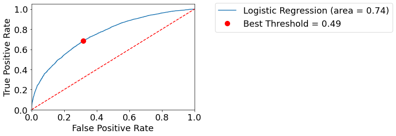

```python
# calculating necessary values
logit_roc_auc = 0.7430920109830258
y=training_data.scorevalue
ypred = logit_model.predict(training_data)
fpr, tpr, auc_thresholds = roc_curve(y, ypred)

# Finding the best threshold to maximize accuracy
logit_roc_auc = 0.7430920109830258
o_tpr = tpr[np.argmin(np.abs(fpr+tpr-1))]
o_fpr = fpr[np.argmin(np.abs(fpr+tpr-1))]
o_threshold = auc_thresholds[np.argmin(np.abs(fpr+tpr-1))]
plt.figure()
plt.plot(fpr, tpr, label='Logistic Regression (area = %0.2f)' % logit_roc_auc)
plt.plot([0, 1], [0, 1],'r--')
plt.plot(o_fpr, o_tpr, 'ro', label='Best Threshold = %0.2f' % o_threshold)
plt.xlim([0.0, 1.0])
plt.ylim([0.0, 1.05])
plt.xlabel('False Positive Rate')
plt.ylabel('True Positive Rate')
plt.legend(bbox_to_anchor=(1.1, 1.05))
plt.show()
```

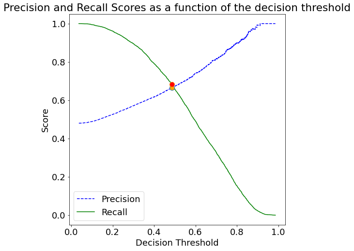

```python
# calculating necessary values
y=training_data.scorevalue
ypred = logit_model.predict(training_data)
p, r, thresholds = precision_recall_curve(y, ypred)

# finding precision and recall values for optimized threshold value
optimal_idx = np.where(thresholds==auc_thresholds[np.argmin(np.abs(fpr+tpr-1))])

def plot_precision_recall_vs_threshold(precisions, recalls, thresholds):
    plt.figure(figsize=(8, 8))
    plt.title("Precision and Recall Scores as a function of the decision threshold")
    plt.plot(thresholds, precisions[:-1], "b--", label="Precision")
    plt.plot(thresholds, recalls[:-1], "g-", label="Recall")
    plt.ylabel("Score")
    plt.xlabel("Decision Threshold")
    plt.legend(loc='best')
    plt.legend()
plot_precision_recall_vs_threshold(p, r, thresholds)
plt.plot(thresholds[optimal_idx],p[optimal_idx],marker="o", markersize=10, markerfacecolor="orange")
plt.plot(thresholds[optimal_idx],r[optimal_idx],marker="o", markersize=10, markerfacecolor="red")
```

### 3.1 Code fitting the final model

Put the code(s) that fit the final model(s) in separate cell(s), i.e., the code with the `.ols()` or `.logit()` functions.

```python
# Building the model using the transformed predictors as well as the best subset of predictors found during best subset selection
logit_model = sm.logit(formula = 'scorevalue~log_mktcap+debt_assets+log_mktcap_log_currratio+log_mktcap_debt_assets+log_currratio_roe+log_currratio_debt_assets+roe_debt_assets+csasectorname+debt_assets1+debt_assets2+debt_assets3+debt_assets4+debt_assets5+debt_assets6+debt_assets7+debt_assets8+debt_assets9', data = training_data).fit()
logit_model.summary()
```

```
Optimization terminated successfully.
         Current function value: 0.587200
         Iterations 6
```

Logit Regression Results

| Dep. Variable: | scorevalue | No. Observations: | 11773 |
| --- | --- | --- | --- |
| Model: | Logit | Df Residuals: | 11746 |
| Method: | MLE | Df Model: | 26 |
| Date: | Tue, 07 Mar 2023 | Pseudo R-squ.: | 0.1518 |
| Time: | 15:56:17 | Log-Likelihood: | -6913.1 |
| converged: | True | LL-Null: | -8150.7 |
| Covariance Type: | nonrobust | LLR p-value: | 0.000 |

|  | coef | std err | z | P>\|z\| | [0.025 | 0.975] |
| --- | --- | --- | --- | --- | --- | --- |
| Intercept | -9.6427 | 1.004 | -9.607 | 0.000 | -11.610 | -7.675 |
| csasectorname[T.Consumer Discretionary] | 1.0706 | 0.125 | 8.588 | 0.000 | 0.826 | 1.315 |
| csasectorname[T.Consumer Staples] | 1.2814 | 0.139 | 9.202 | 0.000 | 1.008 | 1.554 |
| csasectorname[T.Energy] | 1.2789 | 0.141 | 9.063 | 0.000 | 1.002 | 1.555 |
| csasectorname[T.Financials] | 1.0857 | 0.194 | 5.609 | 0.000 | 0.706 | 1.465 |
| csasectorname[T.Health Care] | 0.6537 | 0.126 | 5.169 | 0.000 | 0.406 | 0.902 |
| csasectorname[T.Industrials] | 1.4517 | 0.124 | 11.738 | 0.000 | 1.209 | 1.694 |
| csasectorname[T.Information Technology] | 1.0799 | 0.123 | 8.792 | 0.000 | 0.839 | 1.321 |
| csasectorname[T.Materials] | 1.9563 | 0.138 | 14.168 | 0.000 | 1.686 | 2.227 |
| csasectorname[T.Real Estate] | 0.4983 | 0.398 | 1.251 | 0.211 | -0.283 | 1.279 |
| csasectorname[T.Utilities] | 1.4832 | 0.146 | 10.129 | 0.000 | 1.196 | 1.770 |
| log_mktcap | 0.3572 | 0.045 | 8.013 | 0.000 | 0.270 | 0.445 |
| debt_assets | -8.0657 | 1.741 | -4.633 | 0.000 | -11.478 | -4.653 |
| log_mktcap_log_currratio | -0.0055 | 0.004 | -1.269 | 0.204 | -0.014 | 0.003 |
| log_mktcap_debt_assets | 0.3537 | 0.075 | 4.720 | 0.000 | 0.207 | 0.501 |
| log_currratio_roe | 0.1100 | 0.033 | 3.349 | 0.001 | 0.046 | 0.174 |
| log_currratio_debt_assets | 0.0593 | 0.158 | 0.376 | 0.707 | -0.249 | 0.368 |
| roe_debt_assets | -0.1133 | 0.030 | -3.820 | 0.000 | -0.171 | -0.055 |
| debt_assets1 | 0.3656 | 0.123 | 2.973 | 0.003 | 0.125 | 0.607 |
| debt_assets2 | 0.4666 | 0.161 | 2.906 | 0.004 | 0.152 | 0.781 |
| debt_assets3 | 0.5786 | 0.190 | 3.039 | 0.002 | 0.205 | 0.952 |
| debt_assets4 | 0.7014 | 0.218 | 3.223 | 0.001 | 0.275 | 1.128 |
| debt_assets5 | 0.5920 | 0.246 | 2.405 | 0.016 | 0.109 | 1.074 |
| debt_assets6 | 0.6923 | 0.274 | 2.525 | 0.012 | 0.155 | 1.230 |
| debt_assets7 | 0.8214 | 0.311 | 2.642 | 0.008 | 0.212 | 1.431 |
| debt_assets8 | 1.0873 | 0.361 | 3.010 | 0.003 | 0.379 | 1.795 |
| debt_assets9 | 0.6764 | 0.408 | 1.657 | 0.098 | -0.124 | 1.476 |

```
Classification accuracy = 68.2%
```

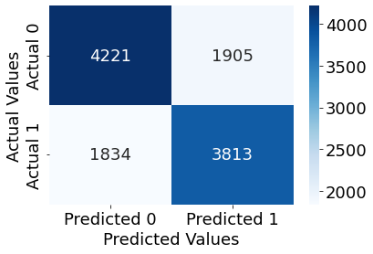

```python
# printing confusion matrix train
confusion_matrix_train(logit_model)
```

```
Classification accuracy = 69.2%
```

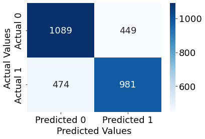

```python
# printing confusion matrix test
confusion_matrix_test(testing_data,testing_data.scorevalue,logit_model)
```